# Reproducible Research Assignment 1

## Loading & Preprocessing Data

In this code chunk the data will be downloaded, loaded into memory, and preprocessed.

```r
library(tidyverse)
library(lattice)

#read in the data & store copy
data <- read.csv("activity.csv")
main <- data
main$date <- as.Date(main$date)
```

## Mean Total Number of Steps Taken Per Day?

Answer the following question:  
1. Calculate the total number of steps taken per day

2. If you do not undertand the difference between a histogram and a barplot, research the difference between them. Make a histogram of the total number of steps taken each day

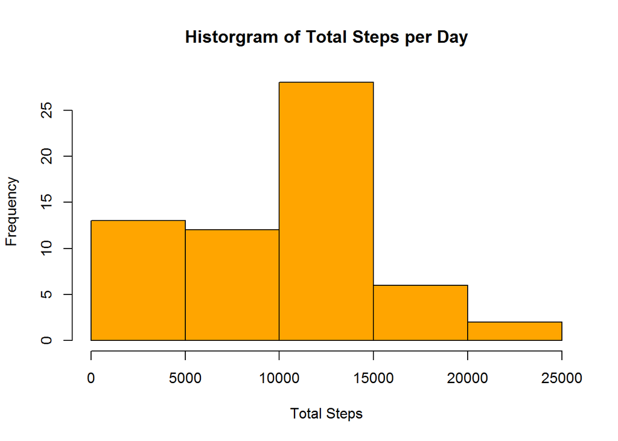

```r
#Calculate  steps per day
total_steps <- group_by(main, date)
total_steps <- summarise(total_steps, total = sum(steps, na.rm = TRUE))

#Create Histogram
hist(total_steps$total, main = "Historgram of Total Steps per Day", xlab = "Total Steps", col="orange")
```

```r
#Calculate Mean & Median
mean <- mean(total_steps$total)
median <- median(total_steps$total)
```

3. Calculate and report the mean and median of the total number of steps taken per day.  
   The mean total number of steps per day is **9354.2** & the median total number of steps taken per day is **10395**.

## What is the average daily activity pattern?

1. Make a time series plot of the 5-minute interval and the average number of steps taken, average across all days.

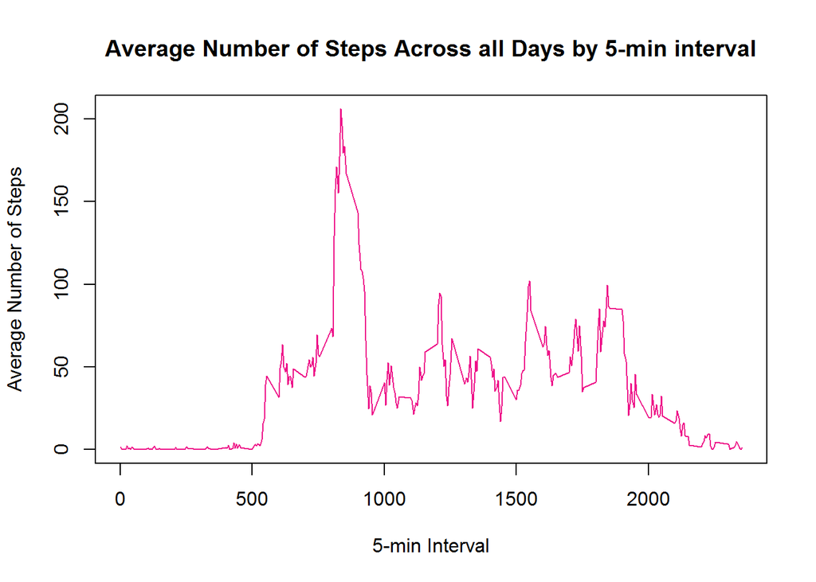

```r
#Group data by interval & calculate mean steps
tsdata <- group_by(main, interval)
tsdata <- summarise(tsdata, meansteps = mean(steps, na.rm = TRUE))

#Create Histogram
plot(tsdata$interval, tsdata$meansteps,
     type = "l",
     ylab = "Average Number of Steps",
     xlab = "5-min Interval",
     col = "#EE1289",
     main = "Average Number of Steps Across all Days by 5-min interval")
```

```r
#Calculate the interval at which the max number of mean steps
interval <- tsdata[which.max(tsdata$meansteps), 1]
```

2. Which 5-minute interval, on average across all the days in the dataset, contains the maximum number of steps? The 5-minute interval that contains the maximum number of steps is **835**